# R Data files, plot and modeling

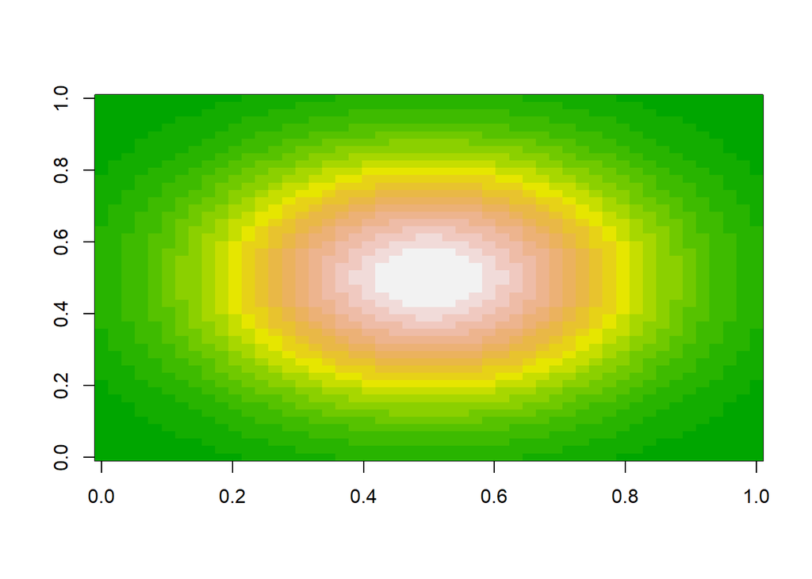

```r
image(normal.mat, col=terrain.colors(20)) # Terrain colors
```

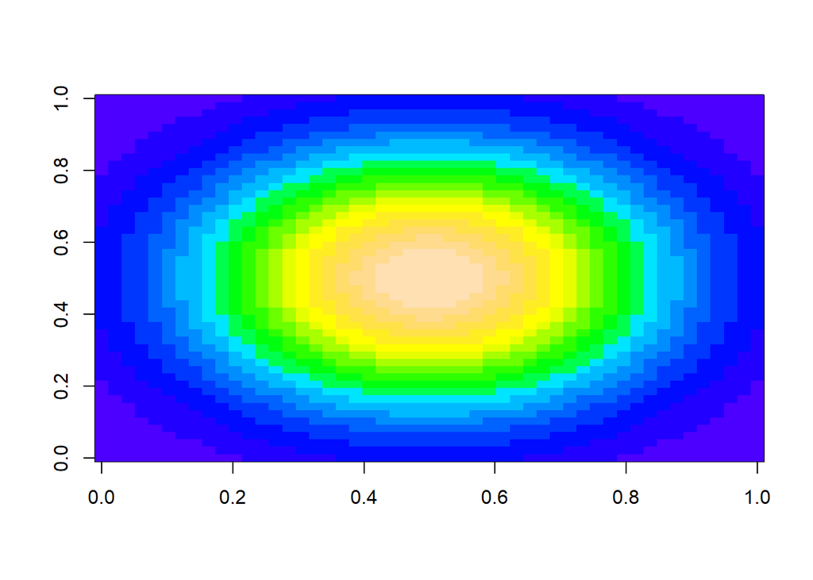

```r
image(normal.mat, col=topo.colors(20)) # Topological colors
```

To draw contour lines from a numeric matrix, use contour(); to add contours to an existing plot (like, a heatmap), use contour() with add=TRUE

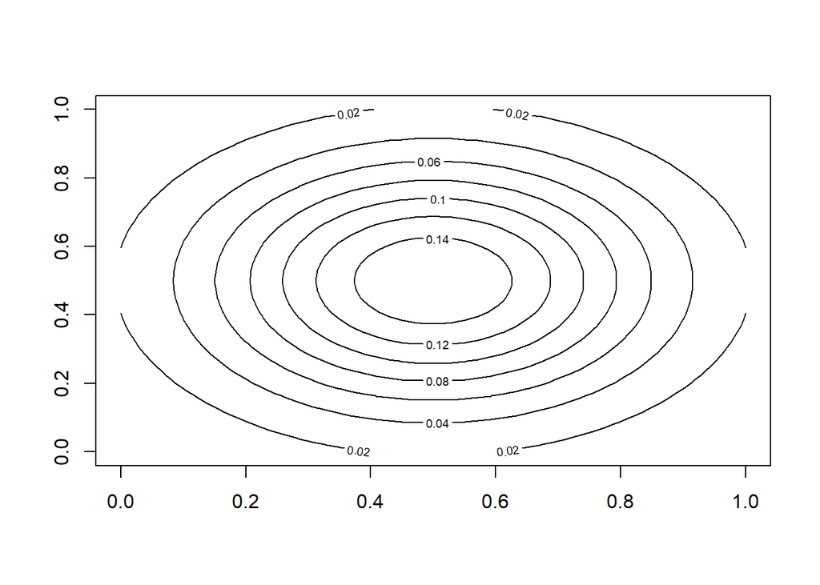

```r
contour(normal.mat)
```

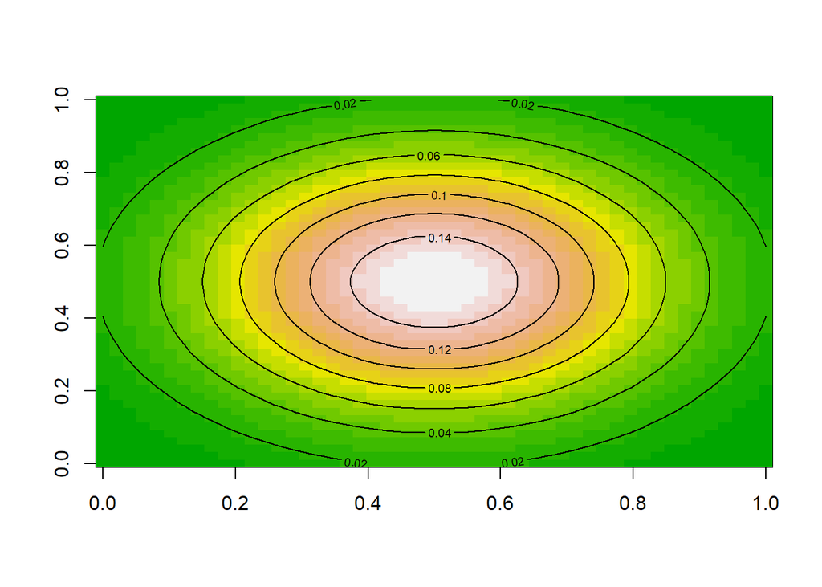

```r
image(normal.mat, col=terrain.colors(20))
contour(normal.mat, add=TRUE)
```

#### Drawing a curve

To draw a curve of a function, use curve()

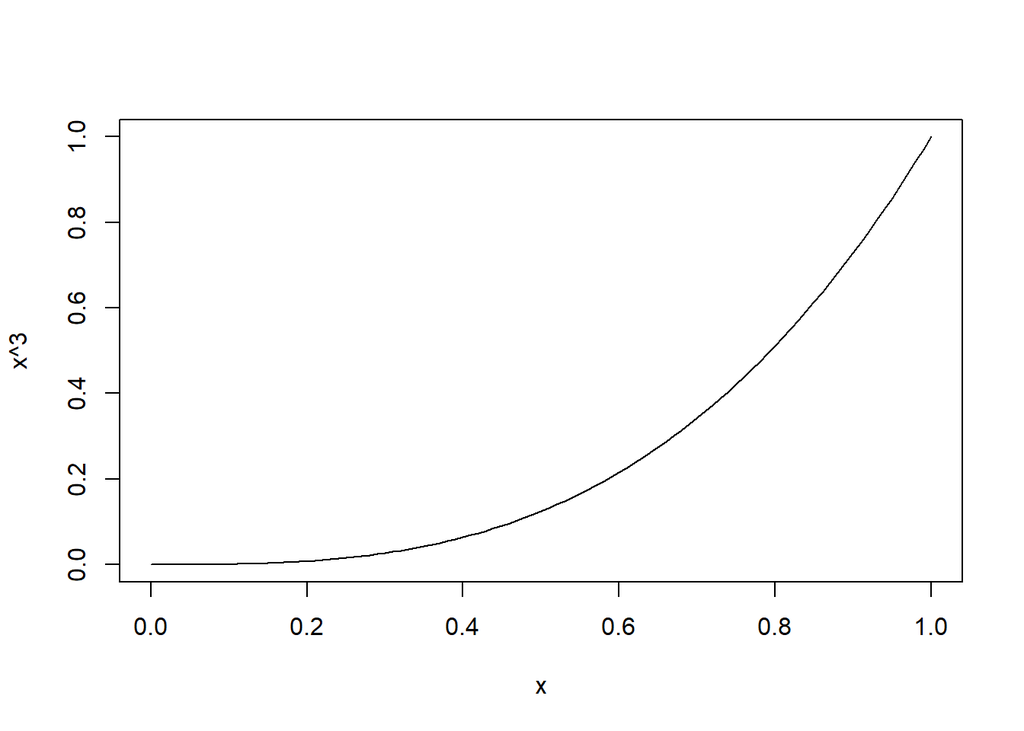

```r
rm(x)
# x
curve(x^3) # Default is to plot between 0 and 1. Note: x here is a symbol
```

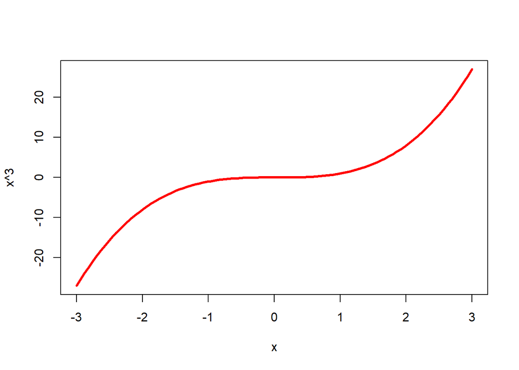

```r
curve(x^3, from=-3, to=3, lwd=3, col="red") # More plotting options
```

#### You can plot anything!

The field of visualization has been filled with nerds,geeks, and hackers, because …. you can plot anything. You can edit images as you like (e.g., ggimage package), make MEME (e.g., meme package), or create animation (e.g., animation). We will not go that far, but there are still plenty to play with. The following is an example.

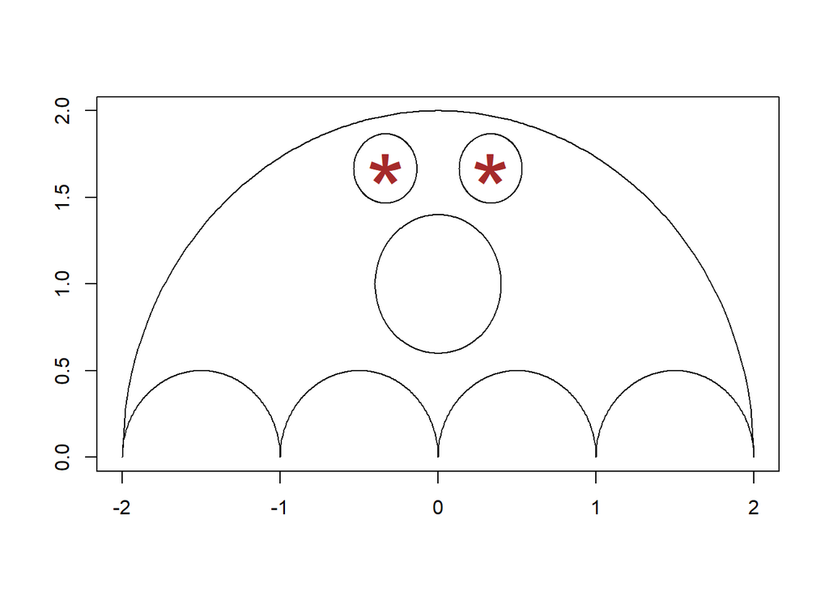

```r
x0 = (0:200-100)/100
y0 = sqrt(1-x0^2)
center.top.x=0
center.top.y=0
radius.top=2
radius.bottom=radius.top/4
center.bottom.y=0
center.bottom.x = center.top.x+radius.bottom*c(-3,-1,1,3)
center.eyes.x = c(-1,1)*radius.top/6+center.top.x
center.eyes.y = radius.top*5/6+center.top.y
center.mouth.x = center.top.x
center.mouth.y = radius.top*0.5+center.top.y
radius.eyes = radius.top*0.1
radius.mouth = radius.top*0.2

plot(center.top.x,center.top.y,type='n',xlim = c(-radius.top,radius.top)+center.top.x,ylim = center.top.y+c(0,radius.top),xlab = '',ylab = '')
lines(center.top.x+x0*radius.top,center.top.y+y0*radius.top)
lines(center.bottom.x[1]+x0*radius.bottom,center.bottom.y+y0*radius.bottom)
lines(center.bottom.x[2]+x0*radius.bottom,center.bottom.y+y0*radius.bottom)
lines(center.bottom.x[3]+x0*radius.bottom,center.bottom.y+y0*radius.bottom)
lines(center.bottom.x[4]+x0*radius.bottom,center.bottom.y+y0*radius.bottom)
lines(center.eyes.x[1]+x0*radius.eyes,center.eyes.y+y0*radius.eyes)
lines(center.eyes.x[1]+x0*radius.eyes,center.eyes.y-y0*radius.eyes)
lines(center.eyes.x[2]+x0*radius.eyes,center.eyes.y+y0*radius.eyes)
lines(center.eyes.x[2]+x0*radius.eyes,center.eyes.y-y0*radius.eyes)
lines(center.mouth.x+x0*radius.mouth,center.mouth.y+y0*radius.mouth)
lines(center.mouth.x+x0*radius.mouth,center.mouth.y-y0*radius.mouth)
points(center.eyes.x,rep(center.eyes.y,2),pch='*',cex=5,col='brown')
```

## Statistical Modeling in R

#### House Price data

This dataset is from Kaggle The measured variables:

- Avg..Area.Income: Numerical data about the average area of the income where the house is located.
- House.Age: Age of the house in years.
- Number.of.Rooms:
- Number.of.Bedrooms:
- Area.Population: Population of the area where the house is located.
- Price:
- Address: The only textual data in the dataset consisting of the address of the house.

```r
setwd(dir.data)
house.df = read.csv('House_price.csv')
dim(house.df)
```

```
## [1] 4548    7
```

```r
head(house.df)
```

```
##   Avg..Area.Income House.Age Number.of.Rooms Number.of.Bedrooms Area.Population
## 1         79545.46  5.682861        7.009188               4.09        23086.80
## 2         79248.64  6.002900        6.730821               3.09        40173.07
## 3         61287.07  5.865890        8.512727               5.13        36882.16
## 4         63345.24  7.188236        5.586729               3.26        34310.24
## 5         59982.20  5.040555        7.839388               4.23        26354.11
## 6         80175.75  4.988408        6.104512               4.04        26748.43
##       Price                                              Address
## 1 1059033.6 208 Michael Ferry Apt. 674\nLaurabury, NE 37010-5101
## 2 1505890.9 188 Johnson Views Suite 079\nLake Kathleen, CA 48958
## 3 1058988.0  9127 Elizabeth Stravenue\nDanieltown, WI 06482-3489
## 4 1260616.8                            USS Barnett\nFPO AP 44820
## 5  630943.5                           USNS Raymond\nFPO AE 09386
## 6 1068138.1 06039 Jennifer Islands Apt. 443\nTracyport, KS 16077
```

At this moment, we cannot use the address directly in the model, let us remove it for now for simplicity

```r
house.df$Address = NULL
head(house.df)
```

```
##   Avg..Area.Income House.Age Number.of.Rooms Number.of.Bedrooms Area.Population
## 1         79545.46  5.682861        7.009188               4.09        23086.80
## 2         79248.64  6.002900        6.730821               3.09        40173.07
## 3         61287.07  5.865890        8.512727               5.13        36882.16
## 4         63345.24  7.188236        5.586729               3.26        34310.24
## 5         59982.20  5.040555        7.839388               4.23        26354.11
## 6         80175.75  4.988408        6.104512               4.04        26748.43
##       Price
## 1 1059033.6
## 2 1505890.9
## 3 1058988.0
## 4 1260616.8
## 5  630943.5
## 6 1068138.1
```

Some example questions we might be interested in: * What is the relationship between Avg..Area.Population and Price? * What is the relationship between House.Age and Price? * Can we predict Price from the other variables, and how good are the predictions?

#### Exploratory data analysis When you are given a dataset, it is generally a good practice to look at your data by visualization, summary statistics and tables. When done in a structured way, this is called exploratory data analysis. E.g., you might investigate:

- What are the distributions of the variables?
- Are there distinct subgroups of samples?
- Are there any noticeable outliers?
- Are there interesting relationship/trends to model? Distributions of house price variables.

Please also note how the titles are generated with paste()

```r
colnames(house.df) # These are the variables
```

```
## [1] "Avg..Area.Income"   "House.Age"          "Number.of.Rooms"
## [4] "Number.of.Bedrooms" "Area.Population"    "Price"
```

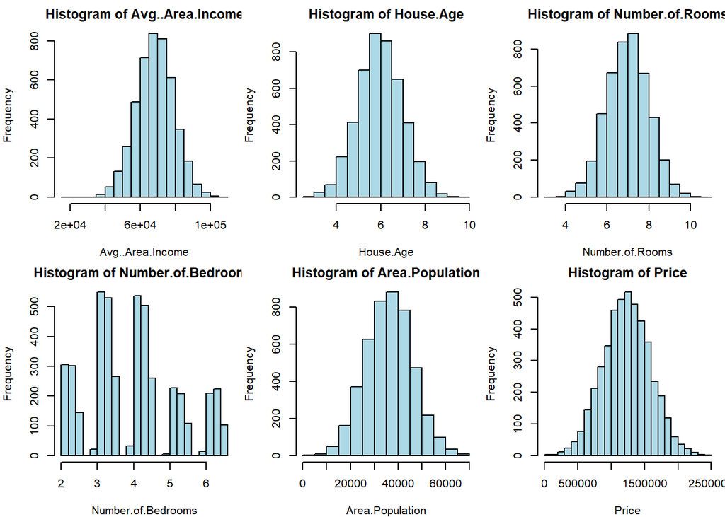

```r
par(mfrow=c(2,3), mar=c(4,4,2,0.5)) # Setup grid, margins
for (j in 1:ncol(house.df)) {
  hist(house.df[,j], xlab=colnames(house.df)[j],
       main=paste("Histogram of", colnames(house.df)[j]),
       col="lightblue", breaks=20)
}
```

What did we learn?

We learned the shapes of the distributions of these variables. If the response variable is skewed, we may need to transform it. What we have looks fine.

We also found that the number of bedrooms are not integers, but clustered around the integers. We floor them for simplicity. Why floor() instead of round()? There are values say, 2.50, but no values between 2.50 and 3.00. So it is more natural to convert 2.50 with 2 instead of 3.

I am not sure why the number of rooms is not an integer neither, maybe from statements such as 2.75 bathrooms. I choose to leave it alone.

```r
house.df$Number.of.Bedrooms = floor(house.df$Number.of.Bedrooms)
```

Next, we look at the correlations between these variables

```r
house.cor = cor(house.df)
round(house.cor,3)
```

```
##                    Avg..Area.Income House.Age Number.of.Rooms
## Avg..Area.Income              1.000    -0.010          -0.007
## House.Age                    -0.010     1.000           0.003
## Number.of.Rooms              -0.007     0.003           1.000
## Number.of.Bedrooms            0.024     0.017           0.470
## Area.Population              -0.007    -0.015          -0.004
## Price                         0.641     0.450           0.342
##                    Number.of.Bedrooms Area.Population Price
## Avg..Area.Income                0.024          -0.007 0.641
## House.Age                       0.017          -0.015 0.450
## Number.of.Rooms                 0.470          -0.004 0.342
## Number.of.Bedrooms              1.000          -0.017 0.183
## Area.Population                -0.017           1.000 0.411
## Price                           0.183           0.411 1.000
```

We did not see any strong correlations, but some moderate ones. Let us find the relatively bigger correlations, and the variable pairs that they represent:

```r
house.cor[lower.tri(house.cor,diag=TRUE)] = 0 # Why only upper tri part?
```

find the indexes of the correlations larger than 0.2 in magnitude. You may change it to higher value if they are more larger correlations.

arr.ind=T tell R that we need their row/column IDs in the matrix, instead of their position in the underlying vector.

```r
arry.ind.big.cor = which(abs(house.cor)>0.2,arr.ind = T)
```

report the larger correlations and the variable pairs (row/coumn names) as a data.frame.

```r
big.cor.w.vars = data.frame(cor=house.cor[arry.ind.big.cor],row=rownames(house.cor)[arry.ind.big.cor[,'row']],col=colnames(house.cor)[arry.ind.big.cor[,'col']])
#  big.cor.w.vars
big.cor.w.vars[order(abs(big.cor.w.vars$cor),decreasing = T),]
```

```
##         cor              row                col
## 2 0.6413816 Avg..Area.Income              Price
## 1 0.4702665  Number.of.Rooms Number.of.Bedrooms
## 3 0.4501336        House.Age              Price
## 5 0.4114532  Area.Population              Price
## 4 0.3415729  Number.of.Rooms              Price
```

The biggest correlation is between the area income and the house price. This is of our interests, and we need to include the average area income into the model that predict house price.

The second biggest correlation is between number of rooms and number of bedrooms. This is not of interests because it is not relevant to our target response (Price), and it is trivial that the number of bedrooms directly contribute to the number of rooms. Visualizing relationships among variables, with pairs()

Can easily look at multiple scatter plots at once, using the pairs() function.

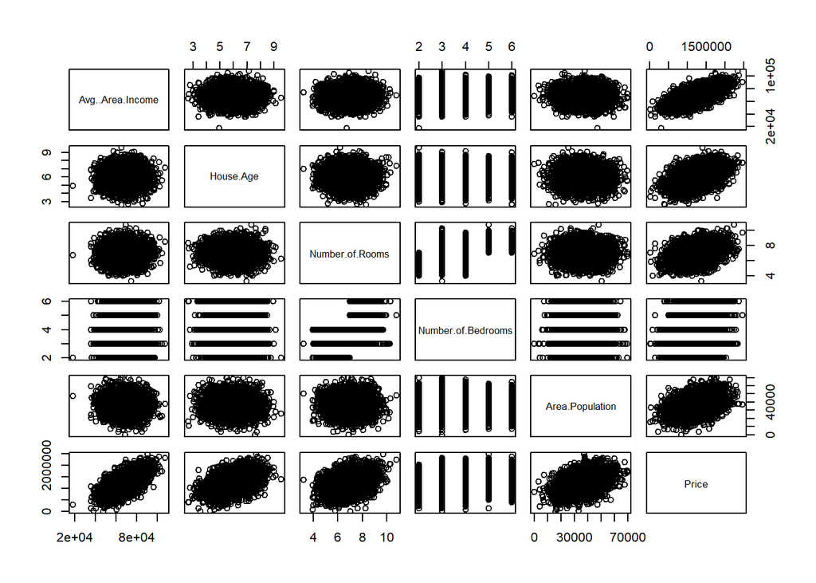

```r
pairs(house.df)
```

pairs(~ Price + Avg..Area.Income + House.Age + Area.Population+ Number.of.Rooms , data=house.df) # If only need to plot for a subset of variables, can put a formula as the first argument.

What a mess! When there are a lot of data points, it is difficult to tell where the bulk of the points lay because a pixel is filled as long as one point is there.

An alternative is to present the density of the point in gray scale using hexbin plot. You need to install the package first.

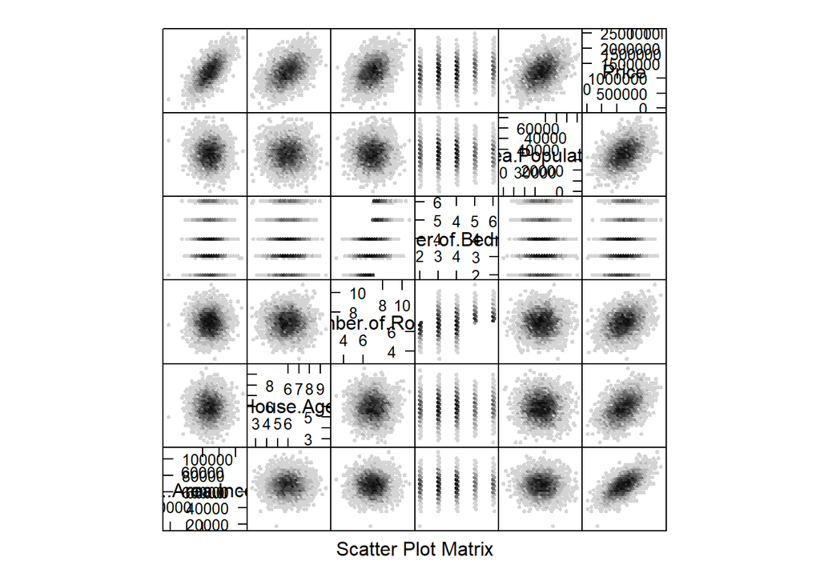

```r
library(hexbin)
hexplom(~ house.df, data=house.df)
```